# Fourth Week: Hypothesis Testing

TIMSS Analysis

Yasmin sarcheshmehpour 94109827

# تمرین سری چهارم: چقدر ریاضی بلدیم و چرا؟

در همه ی موارد فرض صفر برابر است با: دو فیچر گفته شده مستقل از هم هستند و این تفاوت میانگین ها تصادفی است و فرض ha برابر است با: دو فیچر گفته شده مستقل از هم نیستند همچنین آلفا برابر با ۰.۰۵ در نظر گرفته شده است و در همه ی موارد چون pvalue عدد بسیار کوچکی است فرض صفر رد می شود.

```r
library(readr)
library(magrittr)
library(dplyr)
```

```r
library(ggplot2)
bsg = readRDS("/home/sahel/Desktop/tahlil/hw4/bsg.rds")
bst = readRDS("/home/sahel/Desktop/tahlil/hw4/bst.rds")
btm = readRDS("/home/sahel/Desktop/tahlil/hw4/btm.rds")
bcg = readRDS("/home/sahel/Desktop/tahlil/hw4/bcg.rds")
```

۱. میران رضایت معلمان در پیشرفت تحصیلی دانش آموزان موثر است.

```r
bsg %>%
  mutate(score = select(., starts_with("bsmmat")) %>% rowMeans(na.rm = TRUE)) %>%
  select(idcntry, idstud, score)  -> std_data

bst %>% select(idtealin, idcntry, idstud) -> std_tch_data

btm %>% group_by(idcntry, idtealin) %>% select(sat=btdgtjs) -> tch_data
data = full_join(std_data, std_tch_data)
std_tch_sat_data = full_join(data, tch_data)
std_tch_sat_data %>% filter(!is.na(sat)) %>% filter(!is.na(score)) -> std_tch_sat_data
aov(score ~ sat, data = std_tch_sat_data) %>% summary.aov()
```

```
##                 Df    Sum Sq Mean Sq F value Pr(>F)
## sat              1 2.564e+06 2563792   225.1 <2e-16 ***
## Residuals   268539 3.059e+09   11392
## ---
## Signif. codes:  0 '***' 0.001 '**' 0.01 '*' 0.05 '.' 0.1 ' ' 1
```

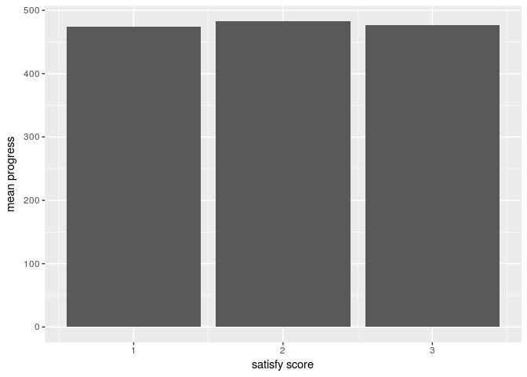

```r
std_tch_sat_data %>% group_by(sat) %>% summarise(count=mean(score)) -> summarise_data
ggplot(summarise_data, aes(x=summarise_data[1], y=summarise_data$count)) +
  geom_bar(stat="identity") +
  guides(fill=FALSE) +
  xlab("satisfy score") + ylab("mean progress")
```

۲. والدینی که تحصیلات بیشتری دارند دارای فرزندان موفق تری می باشند.

```r
bsg %>%
  mutate(score = select(., starts_with("bsmmat")) %>% rowMeans(na.rm = TRUE)) %>%
  filter(!is.na(bsbg07a)) %>% filter(!is.na(bsbg07b)) %>%
  mutate(mean_edu=bsbg07a+bsbg07b/2) %>%
  select(idcntry, idstud, score, mean_edu) -> std_data
aov(score ~ mean_edu, data = std_data) %>% summary.aov()
```

```
##                 Df    Sum Sq  Mean Sq F value Pr(>F)
## mean_edu         1 1.050e+08 1.05e+08    9818 <2e-16 ***
## Residuals   268771 2.876e+09 1.07e+04
## ---
## Signif. codes:  0 '***' 0.001 '**' 0.01 '*' 0.05 '.' 0.1 ' ' 1
```

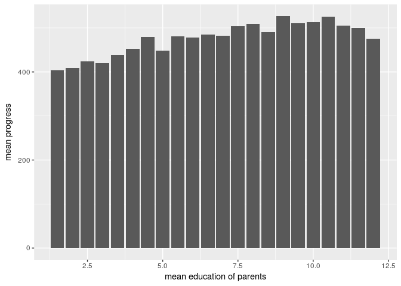

```r
std_data %>% group_by(mean_edu) %>% summarise(mean_score=mean(score)) -> summarise_data
ggplot(summarise_data, aes(x=summarise_data[1], y=summarise_data$mean_score)) +
  geom_bar(stat="identity") +
  guides(fill=FALSE) +
  xlab("mean education of parents") + ylab("mean progress")
```

۳. امکانات رفاهی در خانه موجب پیشرفت تحصیلی می گردد.

```r
bsg %>% select(idstud, idcntry, starts_with("bsbg06"), starts_with("bsmmat")) -> comf
comf[comf == 2] <- 0
comf[comf == 9] <- 0
comf[is.na(comf)] <- 0
comf %>%
  mutate(score = select(., starts_with("bsmmat")) %>% rowMeans(na.rm = TRUE)) %>%
  mutate(mean_comf = select(., starts_with("bsbg06")) %>% rowMeans(na.rm = TRUE)) %>%
  select(score, mean_comf, idstud, idcntry) -> comf
aov(score ~ mean_comf, data = comf) %>% summary.aov()
```

```
##                 Df    Sum Sq   Mean Sq F value Pr(>F)
## mean_comf        1 2.549e+08 254887961   24673 <2e-16 ***
## Residuals   280128 2.894e+09     10331
## ---
## Signif. codes:  0 '***' 0.001 '**' 0.01 '*' 0.05 '.' 0.1 ' ' 1
```

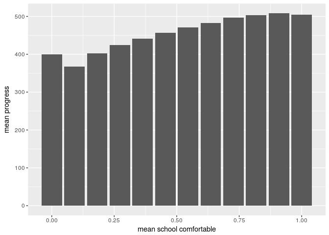

```r
comf %>% group_by(mean_comf) %>% summarise(mean_score=mean(score)) -> summarise_data
ggplot(summarise_data, aes(x=summarise_data[1], y=summarise_data$mean_score)) +
  geom_bar(stat="identity") +
  guides(fill=FALSE) +
  xlab("mean school comfortable") + ylab("mean progress")
```

۴. محیط آرام مدرسه نقش مهمی در پیشرفت تحصیلی دارد.

```r
bcg %>%
  filter(!is.na(bcbg05a)) %>% filter(!is.na(bcbg05b)) %>%
  mutate(calm_score = select(., starts_with("bcbg05")) %>% rowMeans()) %>%
  select(idcntry, idschool, calm_score) -> school_data

bsg %>%
  mutate(score = select(., starts_with("bsmmat")) %>% rowMeans(na.rm = TRUE)) %>%
  select(idcntry, idstud, idschool, score)  -> std_data

calm_data = full_join(std_data, school_data)
aov(score ~ calm_score, data = calm_data) %>% summary.aov()
```

```
##                 Df    Sum Sq   Mean Sq F value Pr(>F)
## calm_score       1 1.523e+08 152292076   14164 <2e-16 ***
## Residuals   262399 2.821e+09     10752
## ---
## Signif. codes:  0 '***' 0.001 '**' 0.01 '*' 0.05 '.' 0.1 ' ' 1
## 17729 observations deleted due to missingness
```

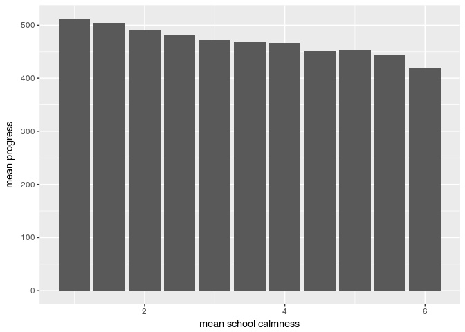

```r
calm_data %>% filter(!is.na(calm_score)) %>%
  group_by(calm_score) %>% summarise(mean_score=mean(score)) -> summarise_data
ggplot(summarise_data, aes(x=summarise_data[1], y=summarise_data$mean_score)) +
  geom_bar(stat="identity") +
  guides(fill=FALSE) +
  xlab("mean school calmness") + ylab("mean progress")
```

۵. معلمان با تحصیلات بالاتر یا تجربه بیشتر دانش آموزان موفق تری تربیت می کنند.

```r
btm %>% group_by(idcntry, idtealin) %>% select(age=btbg01, degree=btbg04) -> tch_data
bsg %>%
  mutate(score = select(., starts_with("bsmmat")) %>% rowMeans(na.rm = TRUE)) %>%
  select(idcntry, idstud, score)  -> std_data

bst %>% select(idtealin, idcntry, idstud) -> std_tch_data

std_tch_sat_data = full_join(full_join(std_data, std_tch_data), tch_data)
std_tch_sat_data %>% filter(!is.na(age)) %>% filter(!is.na(degree)) -> std_tch_sat_data

aov(score ~ age, data = std_tch_sat_data) %>% summary.aov()
```

```
##                 Df    Sum Sq Mean Sq F value Pr(>F)
## age              1 4.094e+06 4093869   363.1 <2e-16 ***
## Residuals   249352 2.812e+09   11275
## ---
## Signif. codes:  0 '***' 0.001 '**' 0.01 '*' 0.05 '.' 0.1 ' ' 1
```

```r
aov(score ~ degree, data = std_tch_sat_data) %>% summary.aov()
```

```
##                 Df    Sum Sq   Mean Sq F value Pr(>F)
## degree           1 1.590e+08 159001565   14924 <2e-16 ***
## Residuals   249352 2.657e+09     10654
## ---
## Signif. codes:  0 '***' 0.001 '**' 0.01 '*' 0.05 '.' 0.1 ' ' 1
```

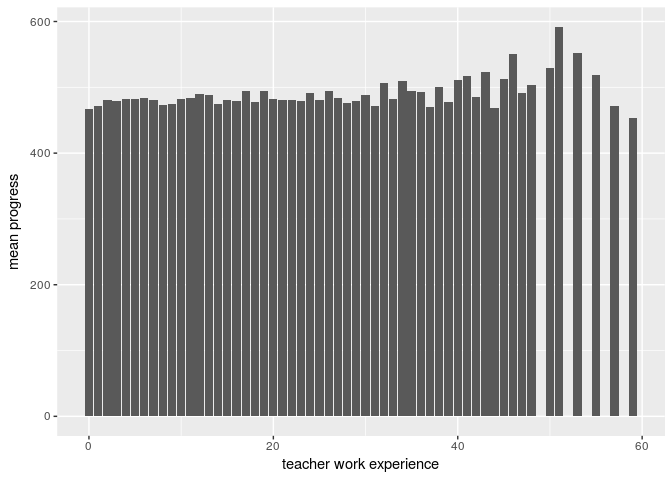

```r
std_tch_sat_data %>% group_by(age) %>% summarise(mean_score=round(mean(score))) %>% arrange(-age)-> summarise_data
ggplot(summarise_data, aes(x=summarise_data[1], y=summarise_data$mean_score)) +
  geom_bar(stat="identity") +
  guides(fill=FALSE) +
  xlab("teacher work experience") + ylab("mean progress")
```

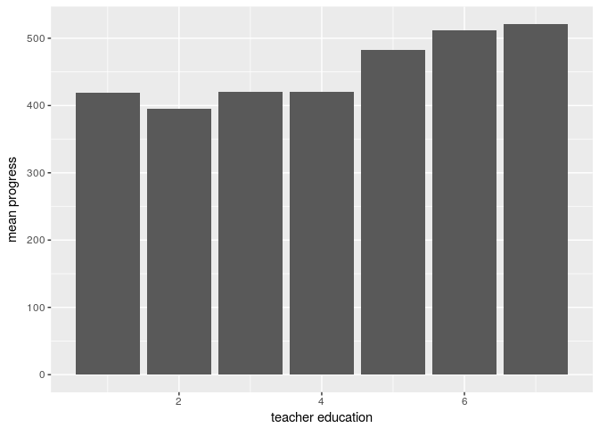

```r
std_tch_sat_data %>% group_by(degree) %>% summarise(mean_score=mean(score)) -> summarise_data
ggplot(summarise_data, aes(x=summarise_data[1], y=summarise_data$mean_score)) +
  geom_col() +
  guides(fill=FALSE) +
  xlab("teacher education") + ylab("mean progress")
```

```r
bsg %>%
  mutate(score = select(., starts_with("bsmmat")) %>% rowMeans(na.rm = TRUE)) %>%
  select(idcntry, idstud, score, itsex )  %>% filter(!is.na(itsex))-> std_data
t.test(score ~ itsex, data = std_data)
```

```
##
##  Welch Two Sample t-test
##
## data:  score by itsex
## t = 5.0161, df = 278750, p-value = 5.275e-07
## alternative hypothesis: true difference in means is not equal to 0
## 95 percent confidence interval:
##  1.224451 2.794974
## sample estimates:
## mean in group 1 mean in group 2
##        477.6906        475.6809
```

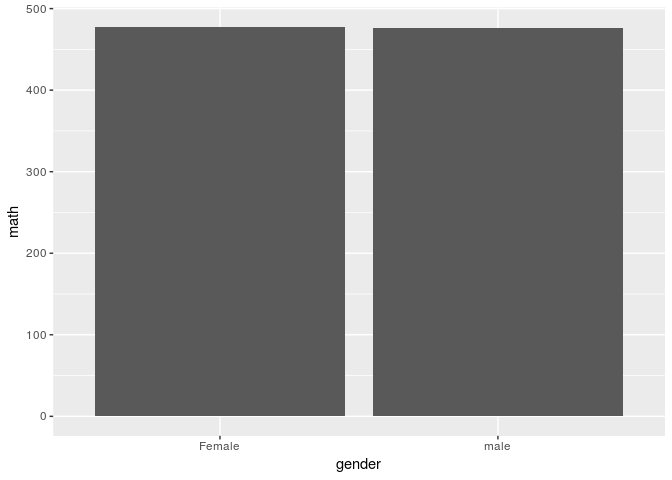

```r
std_data %>% group_by(itsex) %>% summarise(mean_score=mean(score)) -> summarise_data
ggplot(summarise_data, aes(x=c('Female', 'male'), y=summarise_data$mean_score)) +
  geom_col() +
  guides(fill=FALSE) +
  xlab("gender") + ylab("math")
```

۹. علت افت تحصیلی عدم مشارکت در کلاس است.

```r
btm %>% group_by(idcntry, idtealin) %>% select(coll=btbg14d) -> tch_data
bsg %>%
  mutate(score = select(., starts_with("bsmmat")) %>% rowMeans(na.rm = TRUE)) %>%
  select(idcntry, idstud, score)  -> std_data

bst %>% select(idtealin, idcntry, idstud) -> std_tch_data

std_tch_sat_data = full_join(full_join(std_data, std_tch_data), tch_data)
std_tch_sat_data %>% filter(!is.na(coll)) -> std_tch_sat_data
aov(score ~ coll, data = std_tch_sat_data) %>% summary.aov()
```

```
##                 Df    Sum Sq  Mean Sq F value Pr(>F)
## coll             1 2.802e+07 28018848    2479 <2e-16 ***
## Residuals   267082 3.018e+09    11301
## ---
## Signif. codes:  0 '***' 0.001 '**' 0.01 '*' 0.05 '.' 0.1 ' ' 1
```

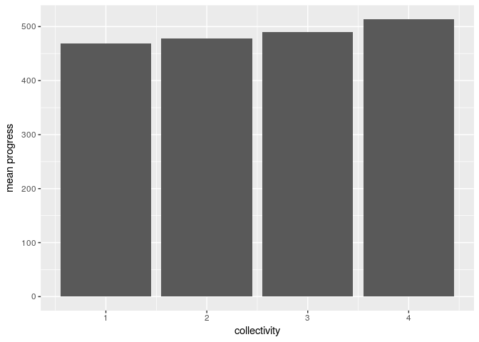

```r
std_tch_sat_data %>% group_by(coll) %>% summarise(mean_score=mean(score)) -> summarise_data
ggplot(summarise_data, aes(x=summarise_data[1], y=summarise_data$mean_score)) +
  geom_col() +
  xlab("collectivity") + ylab("mean progress")
```

سه گزاره جالب کشف کنید و ادعای خود را ثابت نمایید.

سال تحصیلی در میزان پیشرفت دانش آموزان موثر است.

```r
# grade dar pishrafte tahsili tasir dashte ya na
bsg %>%
  mutate(score = select(., starts_with("bsmmat")) %>% rowMeans(na.rm = TRUE)) %>%
  select(idcntry, idstud, score, idgrade)  -> std_data
aov(score ~ idgrade, data = std_data) %>% summary.aov()
```

```
##                 Df    Sum Sq  Mean Sq F value Pr(>F)
## idgrade          1 5.874e+07 58738892    5325 <2e-16 ***
## Residuals   280128 3.090e+09    11031
## ---
## Signif. codes:  0 '***' 0.001 '**' 0.01 '*' 0.05 '.' 0.1 ' ' 1
```

```r
std_data %>% group_by(idgrade) %>% summarise(mean_score=mean(score)) -> summarise_data
summarise_data
```

```
## # A tibble: 2 x 2
##   idgrade mean_score
##     <dbl>      <dbl>
## 1    8.00        482
## 2    9.00        438
```

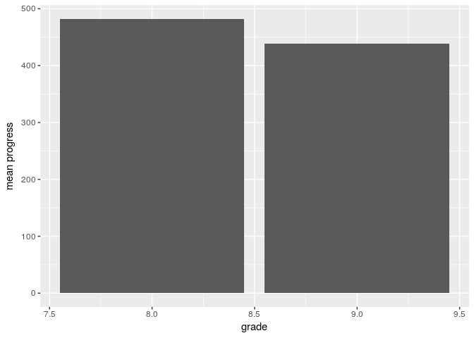

```r
ggplot(summarise_data, aes(x=summarise_data[1], y=summarise_data$mean_score)) +
  geom_col() +
  xlab("grade") + ylab("mean progress")
```

اهمیت عملکرد خوب در ریاضی در پیشرفت تحصیلی دانش آموزان موثر است.

```r
# IMPORTANT TO DO WELL IN MATH dar pishrafte tahsili tasir dare
# 1 2 3 4: Agree a lot" "Agree a little" "Disagree a little" "Disagree a lot"

bsg %>%
  mutate(score = select(., starts_with("bsmmat")) %>% rowMeans(na.rm = TRUE)) %>%
  select(idcntry, idstud, score, imath=bsbm20i)  %>% filter(!is.na(imath)) -> std_data
aov(score ~ imath, data = std_data) %>% summary.aov()
```

```
##                 Df    Sum Sq  Mean Sq F value Pr(>F)
## imath            1 1.862e+07 18617134    1691 <2e-16 ***
## Residuals   272403 2.998e+09    11007
## ---
## Signif. codes:  0 '***' 0.001 '**' 0.01 '*' 0.05 '.' 0.1 ' ' 1
```

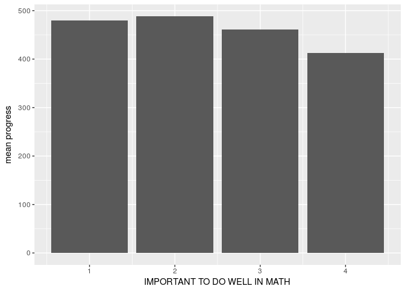

```r
std_data %>% group_by(imath) %>% summarise(mean_score=mean(score)) -> summarise_data
ggplot(summarise_data, aes(x=summarise_data[1], y=summarise_data$mean_score)) +
  geom_col() +
  xlab("IMPORTANT TO DO WELL IN MATH") + ylab("mean progress")
```

میزان سخت بودن ریاضی برای دانش آموزان در پیشرفت تحصیلی آنها موثر است.

```r
# MATHEMATICS IS MORE DIFFICULT dar pishrafte tahsili tasir dare
# 1 2 3 4: Agree a lot" "Agree a little" "Disagree a little" "Disagree a lot"

bsg %>%
  mutate(score = select(., starts_with("bsmmat")) %>% rowMeans(na.rm = TRUE)) %>%
  select(idcntry, idstud, score, dmath=bsbm19b)  %>% filter(!is.na(dmath)) -> std_data
aov(score ~ dmath, data = std_data) %>% summary.aov()
```

```
##                 Df    Sum Sq   Mean Sq F value Pr(>F)
## dmath            1 3.603e+08 360306192   36834 <2e-16 ***
## Residuals   272797 2.668e+09      9782
## ---
## Signif. codes:  0 '***' 0.001 '**' 0.01 '*' 0.05 '.' 0.1 ' ' 1
```

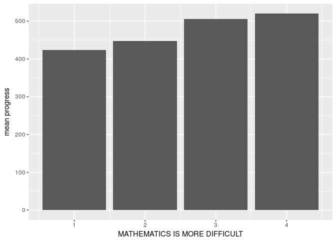

```r
std_data %>% group_by(dmath) %>% summarise(mean_score=mean(score)) -> summarise_data
ggplot(summarise_data, aes(x=summarise_data[1], y=summarise_data$mean_score)) +
  geom_col() +
  xlab("MATHEMATICS IS MORE DIFFICULT") + ylab("mean progress")
```